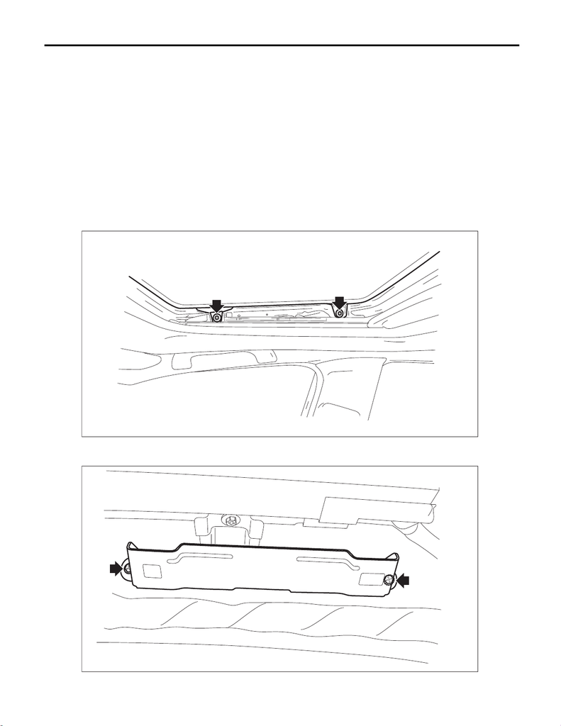

SR-11

Sunroof Assembly

SUNROOF/T-TOP/CONVERTIBLE TOP (SUNROOF)

5. Sunroof Assembly

A: REMOVAL

1) Disconnect the ground cable from battery. <Ref. to NT-5, BATTERY, NOTE, Note.>

NOTE:

• Completely close the lid assembly - sunroof, then disconnect the ground cable.

• For models other than STI model, disconnect the ground terminal from battery sensor.

2) Remove the lid assembly - sunroof.

CAUTION:

Be careful not to damage the lid assembly - sunroof.

(1) Completely close the lid assembly - sunroof, and open the sunshade assembly.

(2) Remove the lid assembly - sunroof.

Preparation tool:

TORX

®

T25

3) Remove the trim panel - roof assembly. <Ref. to EI-99, REMOVAL, Roof Trim.>

4) Remove the bracket - assist rail.

5) Disconnect the connector of the motor assembly - sunroof.

SR-00187

SR-00196

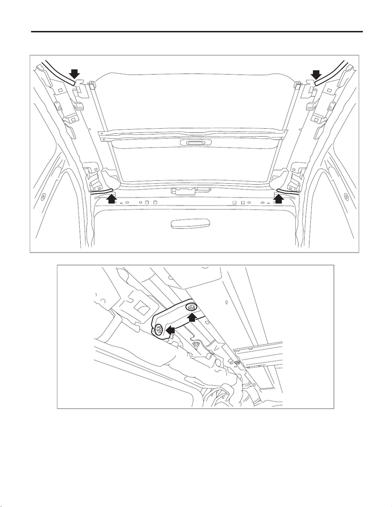

SR-12

Sunroof Assembly

SUNROOF/T-TOP/CONVERTIBLE TOP (SUNROOF)

6) Remove the rail assembly - sunroof.

(1) Remove the drain tube - sunroof.

(2) Remove the bolts and then remove the sunroof bracket.

SR-00195

SR-00166

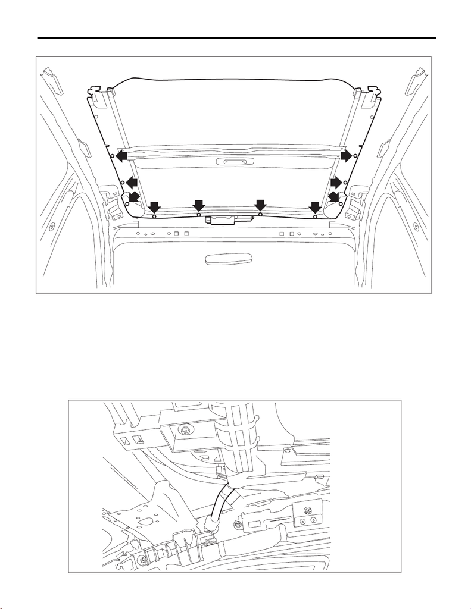

SR-13

Sunroof Assembly

SUNROOF/T-TOP/CONVERTIBLE TOP (SUNROOF)

(3) Remove the bolts, then remove the rail assembly.

B: INSTALLATION

CAUTION:

Be careful not to snag the harness.

1) Install the sunroof bracket and the rail assembly - sunroof.

Tightening torque:

6 N·m (0.6 kgf-m, 4.4 ft-lb)

2) Connect the harness connector of the drain tube - sunroof and the motor assembly.

CAUTION:

Insert the four drain tubes 15 mm (0.59 in) or more into the drain pipes (A).

SR-00197

SR-00169

A

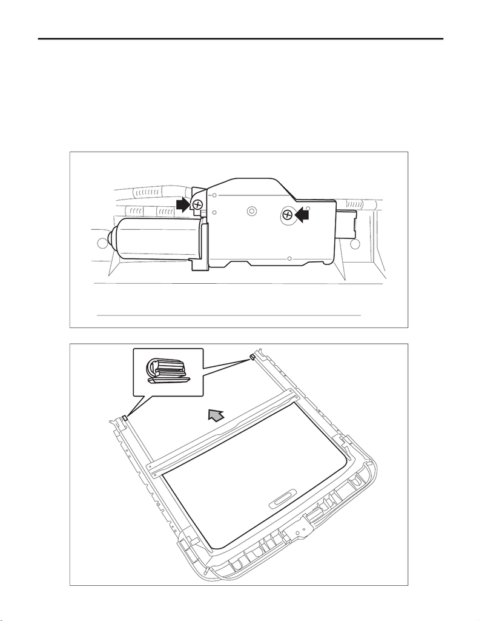

SR-14

Sunroof Assembly

SUNROOF/T-TOP/CONVERTIBLE TOP (SUNROOF)

3) Install the bracket - assist rail.

Tightening torque:

7.5 N·m (0.8 kgf-m, 5.5 ft-lb)

4) Install the trim panel - roof assembly. <Ref. to EI-102, INSTALLATION, Roof Trim.>

5) Using a new TORX

®

bolt, install the lid assembly - sunroof.

Tightening torque:

4.5 N·m (0.5 kgf-m, 3.3 ft-lb)

C: DISASSEMBLY

SR-00198

SR-00199

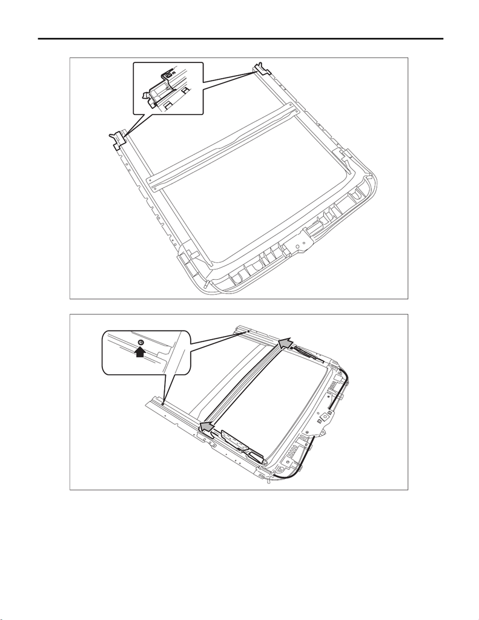

SR-15

Sunroof Assembly

SUNROOF/T-TOP/CONVERTIBLE TOP (SUNROOF)

3) Disconnect the claws and then remove the drain holder.

4) Remove the screw and pull out the cable assembly from the rail assembly - sunroof.

D: ASSEMBLY

1) Insert the cable assembly into the rail assembly - sunroof.

2) Install the drain holder.

3) Insert the sunshade assembly into the rail assembly - sunroof, and install the stopper rubber.

4) Install the sunroof motor.

SR-00200

SR-00181